# Laboratorio 11: Texto como datos

Ciencia de Datos y Econometría Aplicada

Author

Affiliation

Ignacio Sarmiento-Barbieri

Universidad de los Andes

# Introducción

La [CEPAL](https://www.cepal.org) publica la *Revista CEPAL* desde 1976. Es una de las revistas más leídas sobre economía y desarrollo de América Latina. Sus artículos, y sus resúmenes, están en acceso abierto en el [repositorio de la CEPAL](https://repositorio.cepal.org).

En este laboratorio trabajamos con los resúmenes en español de todos sus artículos desde 1980.

Puntualmente queremos analizar **¿cómo cambió el lenguaje del desarrollo en América Latina en las últimas cinco décadas?**

# Configuración del proyecto

Las carpetas usuales:

```
Laboratorio_11/
├── 01_Datos/
├── 02_Scripts/
└── 03_Resultados/
```

Atajos para crearlas más rápido, en **macOS**:

```bash
mkdir -p Laboratorio_11/01_Datos Laboratorio_11/02_Scripts Laboratorio_11/03_Resultados
```

o en **Windows (PowerShell)**:

```powershell
mkdir Laboratorio_11\01_Datos, Laboratorio_11\02_Scripts, Laboratorio_11\03_Resultados
```

## Paquetes

Usamos `pacman` para manejar los paquetes y `tidyverse`, como siempre, para trabajar los datos.

```r
library(pacman)
p_load("tidyverse")
```

Además necesitamos varios paquetes nuevos:

- [`tidytext`](https://juliasilge.github.io/tidytext/), de Julia Silge y David Robinson, trae al texto la lógica *tidy*.
- [`stopwords`](https://github.com/quanteda/stopwords) trae listas de palabras vacías en muchos idiomas, incluido el español.
- [`SnowballC`](https://cran.r-project.org/package=SnowballC) implementa el *stemmer* de Snowball.
- [`tm`](https://cran.r-project.org/package=tm) es el paquete clásico de minería de texto en R. No lo usamos directamente, pero ciertas funciones, como `cast_dtm()`, lo necesitan.

```r
p_load("tidytext", "stopwords", "SnowballC", "tm")
```

Y para la última parte:

- [`widyr`](https://github.com/juliasilge/widyr) calcula correlaciones y conteos entre pares de palabras.
- [`ggraph`](https://ggraph.data-imaginist.com) e [`igraph`](https://r.igraph.org) nos permiten dibujar fácilmente redes con la gramática de `ggplot2`.

```r
p_load("widyr", "igraph", "ggraph")
```

# Datos

Los datos están en el repositorio del curso. En `02_Scripts/01_datos.R`:

```r
# ==============================================================================
# 01_datos.R
# Autor: Ignacio Sarmiento-Barbieri
# Descripción: Descarga los resúmenes de la Revista CEPAL, conserva los artículos desde 1980, crea la década y guarda cepal.rds en 01_Datos.
# ==============================================================================

library(pacman)
p_load("tidyverse")

URL <- "https://raw.githubusercontent.com/ignaciomsarmiento/datasets/main/revista_cepal.csv"
cepal <- read_csv(URL, show_col_types = FALSE)
```

Cada fila es un artículo:

```r
glimpse(cepal)
```

```
Rows: 939
Columns: 7
$ id      <chr> "oai:repositorio.cepal.org:11362/12267", "oai:repositorio.cepa…
$ anio    <dbl> 1976, 1981, 1981, 1981, 1981, 1981, 1982, 1982, 1982, 1982, 19…
$ titulo  <chr> "Notas sobre los estilos de desarrollo en América Latina", "Pr…
$ autores <chr> "Pinto Santa Cruz, Aníbal", NA, "Cohen Orantes, Isaac", "Fajnz…
$ temas   <chr> "DEVELOPMENT MODELS; ECONOMIC ANALYSIS; ANALISIS ECONOMICO; MO…
$ resumen <chr> "La discusión sobre estilos de desarrollo se ha visto complica…
$ url     <chr> "https://hdl.handle.net/11362/12267", "https://hdl.handle.net/…
```

Nos quedamos con los artículos desde 1980 (hay uno solo de los setenta) y creamos la década:

```r
cepal <- cepal %>%
  filter(anio >= 1980) %>%
  mutate(decada = 10 * (anio %/% 10))
```

Veamos cuántos artículos hay por década:

```r
count(cepal, decada)
```

```
# A tibble: 5 × 2
  decada     n
   <dbl> <int>
1   1980   112
2   1990   168
3   2000   192
4   2010   274
5   2020   192
```

Y uno de los resúmenes de 2021:

```r
cepal$resumen[cepal$anio == 2021][1]
```

```
[1] "El propósito de este trabajo es identificar las variables que determinan la productividad laboral en El Salvador. Los resultados indican que la extrema apertura de su economía, así como la caída de su tasa de inversión desde mediados de los años noventa, han constituido frenos al dinamismo de l…
```

Guardamos la muestra:

```r
saveRDS(cepal, "01_Datos/cepal.rds")
```

# Tokenizar

Para poder analizar el texto necesitamos definir la unidad de análisis, nuestro token; hoy serán las palabras. Para ello usaremos el formato de `tidytext` que es un formato largo. Es decir, en `02_Scripts/02_tokens.R`, pasamos de un resumen por fila a **una palabra por fila** con `unnest_tokens()`. El primer argumento es el nombre de la columna nueva y el segundo, la columna con el texto:

```r
# ==============================================================================
# 02_tokens.R
# Autor: Ignacio Sarmiento-Barbieri
# Descripción: Tokeniza los resúmenes, y los examina.
# ==============================================================================

library(pacman)
p_load("tidyverse", "tidytext", "stopwords", "SnowballC")

cepal <- readRDS("01_Datos/cepal.rds")

tokens <- cepal %>%
  select(id, anio, decada, resumen) %>%
  unnest_tokens(word, resumen)

tokens
```

```
# A tibble: 142,948 × 4
   id                                     anio decada word
   <chr>                                 <dbl>  <dbl> <chr>
 1 oai:repositorio.cepal.org:11362/10276  1981   1980 presenta
 2 oai:repositorio.cepal.org:11362/10276  1981   1980 en
 3 oai:repositorio.cepal.org:11362/10276  1981   1980 forma
 4 oai:repositorio.cepal.org:11362/10276  1981   1980 sucinta
 5 oai:repositorio.cepal.org:11362/10276  1981   1980 una
 6 oai:repositorio.cepal.org:11362/10276  1981   1980 evaluación
 7 oai:repositorio.cepal.org:11362/10276  1981   1980 de
 8 oai:repositorio.cepal.org:11362/10276  1981   1980 los
 9 oai:repositorio.cepal.org:11362/10276  1981   1980 problemas
10 oai:repositorio.cepal.org:11362/10276  1981   1980 centrales
# ℹ 142,938 more rows
```

Notemos que `unnest_tokens()` hizo una limpieza preliminar, pasando todo a minúsculas y quitando la puntuación. Pasamos de 938 filas (documentos) a 142.948.

¿Cuáles son las palabras más frecuentes?

```r
tokens %>%
  count(word, sort = TRUE) %>%
  head(15)
```

```
# A tibble: 15 × 2
   word      n
   <chr> <int>
 1 de    12322
 2 la     7560
 3 en     5190
 4 y      4936
 5 el     4125
 6 los    3816
 7 que    3099
 8 las    2960
 9 se     2601
10 a      2274
11 del    2018
12 un     1273
13 para   1160
14 una    1123
15 con    1024
```

En el lenguaje, unas pocas palabras concentran gran parte de la distribución, mientras que la mayoría se utiliza con muy poca frecuencia. Este patrón se conoce como **ley de Zipf**: al ordenar las palabras de mayor a menor frecuencia, la segunda suele aparecer aproximadamente la mitad de veces que la primera; la tercera, un tercio, y así sucesivamente. Estadísticamente, esto implica una relación inversa entre la frecuencia y el rango de cada palabra que, al representarse en escala log-log, se aproxima a una línea recta con pendiente de $-1$.

Para observar este patrón, ordenemos las palabras según su frecuencia y grafiquemos la frecuencia relativa frente a su posición en el ranking, utilizando escalas logarítmicas en ambos ejes:

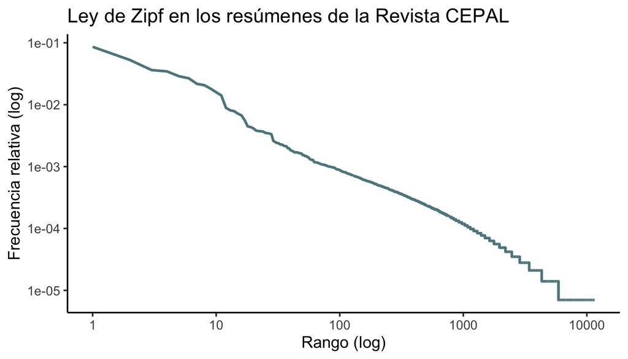

```r
zipf <- tokens %>%
  count(word, sort = TRUE) %>%
  mutate(rango = row_number(),
         frecuencia = n / sum(n))

ggplot(zipf, aes(rango, frecuencia)) +
  geom_line(colour = "#5D878E", linewidth = 1) +
  scale_x_log10() +
  scale_y_log10() +
  labs(x = "Rango (log)", y = "Frecuencia relativa (log)",
       title = "Ley de Zipf en los resúmenes de la Revista CEPAL") +
  theme_classic(base_size = 13)
```

```r
ggsave("03_Resultados/01_zipf.png", width = 7, height = 4)
```

## Limpieza del texto

### Palabras vacías

La ley de Zipf nos revela que las palabras más frecuentes son palabras que no transmiten significado, son palabras “vacías”. Para eliminarlas usamos el paquete `stopwords` que trae una lista de palabras vacías en español. La convertimos en una tabla con una columna `word`, igual que nuestros tokens, para poder quitarlas con `anti_join()`:

```r
vacias <- tibble(word = stopwords::stopwords("es", source = "snowball"))
head(vacias$word, 20)
```

```
 [1] "de"   "la"   "que"  "el"   "en"   "y"    "a"    "los"  "del"  "se"
[11] "las"  "por"  "un"   "para" "con"  "no"   "una"  "su"   "al"   "lo"
```

```r
tokens %>%
  anti_join(vacias, by = "word") %>%
  count(word, sort = TRUE) %>%
  head(15)
```

```
# A tibble: 15 × 2
   word            n
   <chr>       <int>
 1 desarrollo    547
 2 países        532
 3 artículo      476
 4 crecimiento   372
 5 políticas     341
 6 política      325
 7 latina        313
 8 trabajo       306
 9 américa       304
10 resultados    283
11 social        281
12 sector        262
13 económico     258
14 analiza       251
15 mayor         243
```

Podemos ver ahora que aparecen palabras más relacionadas con los temas: *desarrollo*, *países*, *crecimiento*.

### Las tildes

Busquemos “países”, con y sin tilde, por década:

```r
tokens %>%
  filter(word %in% c("países", "paises")) %>%
  count(decada, word) %>%
  pivot_wider(names_from = word, values_from = n, values_fill = 0)
```

```
# A tibble: 5 × 3
  decada paises países
   <dbl>  <int>  <int>
1   1980     42     10
2   1990      0    139
3   2000      0    124
4   2010      0    140
5   2020      0    119
```

Hay claramente un cambio en la década del 90. Necesitamos de cierta forma homogeneizar. Una solución es quitar las tildes a todas las palabras, **y también a la lista de palabras vacías**. La función `stri_trans_general()` del paquete `stringi` (viene con el `tidyverse`) hace la transliteración:

```r
sin_tilde <- function(x) stringi::stri_trans_general(x, "Latin-ASCII")
sin_tilde(c("países", "economía", "año", "política"))
```

```
[1] "paises"   "economia" "ano"      "politica"
```

Notemos que también la ñ se convierte en n (“año” pasa a “ano”). Es un costo que aquí podemos aceptar.

Unos resúmenes traen frases en inglés, así que agregamos también las palabras vacías en inglés:

```r
vacias <- tibble(word = sin_tilde(c(stopwords::stopwords("es", source = "snowball"),
                                    stopwords::stopwords("en"))))
```

Quitemos entonces las vacías y los números, y miremos de nuevo:

```r
limpios <- tokens %>%
  mutate(word = sin_tilde(word)) %>%
  anti_join(vacias, by = "word") %>%
  filter(!str_detect(word, "[0-9]"))

limpios %>%
  count(word, sort = TRUE) %>%
  head(30)
```

```
# A tibble: 30 × 2
   word            n
   <chr>       <int>
 1 paises        574
 2 desarrollo    551
 3 articulo      476
 4 crecimiento   372
 5 politicas     362
 6 politica      342
 7 america       332
 8 latina        313
 9 trabajo       307
10 resultados    283
# ℹ 20 more rows
```

Algunas de estas palabras no son vacías en español, pero sí en **este** corpus: aparecen en casi todos los resúmenes porque así se escribe un resumen (“en este *artículo* se *analiza*…”).

Armemos una lista, `dominio`, de palabras que, en nuestra opinión, no aportan información sobre el tema del artículo. Incluyo también “seccion”, “ii”, “iii” e “iv”: en los noventa varios resúmenes describen las secciones del artículo.

```r
dominio <- tibble(word = c("articulo", "resultados", "analiza", "estudio",
                           "trabajo", "presente", "seccion", "ii", "iii", "iv"))
```

```r
limpios <- limpios %>%
  anti_join(dominio, by = "word")

saveRDS(limpios, "01_Datos/tokens.rds")
```

### Raíces

Una misma idea puede aparecer en un texto expresada mediante distintas formas de una palabra. Por ejemplo, *economía*, *económico* y *económicas* son palabras diferentes, pero comparten una raíz relacionada con el mismo concepto.

Para agrupar estas variaciones utilizamos una técnica llamada **stemming**, que consiste en reducir las palabras a una raíz común mediante reglas lingüísticas. A diferencia de la lematización, que busca recuperar la forma base de una palabra, el *stemming* elimina o transforma terminaciones. Por eso, las raíces resultantes no necesariamente son palabras que existan en español.

En R podemos aplicar esta técnica con la función `wordStem()` del paquete `SnowballC`. Veamos qué palabras de nuestro corpus se agrupan alrededor de algunas raíces relacionadas con economía, política y desarrollo:

```r
limpios %>%
  mutate(raiz = wordStem(word, language = "spanish")) %>%
  filter(raiz %in% c("econom", "polit", "desarroll")) %>%
  count(raiz, word, sort = TRUE)
```

```
# A tibble: 26 × 3
   raiz      word              n
   <chr>     <chr>         <int>
 1 desarroll desarrollo      551
 2 polit     politicas       362
 3 polit     politica        342
 4 econom    economico       265
 5 econom    economica       220
 6 econom    economicas       73
 7 econom    economicos       71
 8 desarroll desarrollados    37
 9 polit     politicos        32
10 polit     politico         27
# ℹ 16 more rows
```

El resultado permite identificar distintas palabras que el algoritmo asocia con una misma raíz y observar cuántas veces aparece cada una. Esto es útil cuando nos interesa estudiar temas generales y no necesariamente distinguir entre todas las formas de una palabra.

Al agrupar palabras que comparten una raíz, también disminuye el número de términos diferentes que necesitamos analizar. Podemos medir esta reducción comparando la cantidad de palabras únicas antes y después de aplicar *stemming*:

```r
limpios %>%
  mutate(raiz = wordStem(word, language = "spanish")) %>%
  summarise(
    palabras = n_distinct(word),
    raices   = n_distinct(raiz)
  )
```

```
# A tibble: 1 × 2
  palabras raices
     <int>  <int>
1    10859   5770
```

Una reducción del vocabulario puede facilitar el análisis de textos, pues permite reunir información que antes estaba distribuida entre distintas formas de una palabra. Sin embargo, también implica **perder parte de la información lingüística**: dos palabras con significados diferentes pueden terminar compartiendo una raíz.

Hay un detalle importante al trabajar con textos en español: el algoritmo de `SnowballC` utiliza las tildes como parte de sus reglas de transformación. Por lo tanto, eliminar las tildes durante la limpieza del texto puede modificar las raíces que obtenemos.

Por ejemplo:

```r
wordStem(
  c("economía", "economia", "económico", "creció", "crecio"),
  language = "spanish"
)
```

```
[1] "econom"  "economi" "econom"  "crec"    "creci"
```

Aunque algunas palabras solo se diferencian por una tilde, el algoritmo puede procesarlas de manera distinta y producir raíces diferentes.

Esto es clave, ya que las decisiones que tomamos al limpiar un texto afectan los resultados del análisis. Si vamos a utilizar *stemming* en español, conviene conservar las tildes hasta después de aplicar el algoritmo, especialmente cuando queremos agrupar correctamente distintas formas de una misma palabra.

**NoteOpcional: lematización con `udpipe`**

La lematización lleva cada palabra a su forma de diccionario (“creció” → “crecer”, “económicas” → “económico”). En R, para español, la hace [`udpipe`](https://bnosac.github.io/udpipe/en/) con un modelo entrenado que se descarga una sola vez (unos 20 MB). Es más lenta que el *stemming*: para los 938 resúmenes, tarda algunos minutos.

```r
p_load("udpipe")
modelo <- udpipe_download_model(language = "spanish-gsd", model_dir = "01_Datos")
ud <- udpipe_load_model(modelo$file_model)
udpipe_annotate(ud, x = "La economía creció y las políticas económicas cambiaron.") %>%
  as_tibble() %>%
  select(token, lemma, upos)
```

# Frecuencias por década

Estamos listos entonces para analizar las palabras más utilizadas en cada década, en `02_Scripts/03_frecuencias.R`:

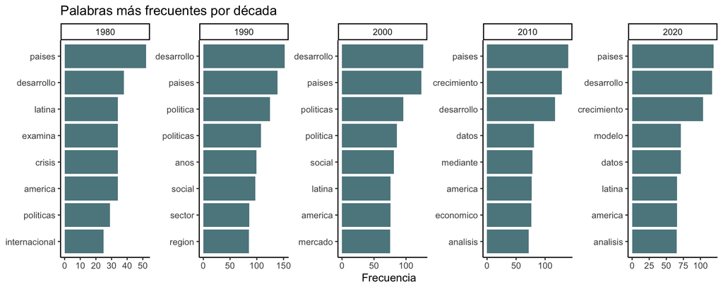

```r
# ==============================================================================
# 03_frecuencias.R
# Autor: Ignacio Sarmiento-Barbieri
# Descripción: Grafica las palabras más frecuentes de cada década con los tokens limpios.
# ==============================================================================

library(pacman)
p_load("tidyverse", "tidytext")

limpios <- readRDS("01_Datos/tokens.rds")

frecuentes <- limpios %>%
  count(decada, word) %>%
  group_by(decada) %>%
  slice_max(n, n = 8, with_ties = FALSE) %>%
  ungroup()

ggplot(frecuentes, aes(n, reorder_within(word, n, decada))) +
  geom_col(fill = "#5D878E") +
  facet_wrap(~ decada, scales = "free", nrow = 1) +
  scale_y_reordered() +
  labs(x = "Frecuencia", y = NULL,
       title = "Palabras más frecuentes por década") +
  theme_classic(base_size = 11)
```

```r
ggsave("03_Resultados/02_frecuencias.png", width = 10, height = 4)
```

`reorder_within()` y `scale_y_reordered()`, de `tidytext`, ordenan las barras dentro de cada panel.

Las listas se parecen mucho entre décadas: *desarrollo*, *paises*, *crecimiento*, *politicas*, *america*, *latina*. Son palabras frecuentes en **todo** el corpus. Para ver qué distingue a cada década necesitamos otra forma de pesar las palabras.

# TF-IDF

Recordemos la definición. Para el término $t$ en el documento $d$:

$$\text{tf}(t,d) = \frac{c_{td}}{\sum_{t'} c_{t'd}}
\qquad
\text{idf}(t) = \ln\left(\frac{D}{\#\{d : c_{td} > 0\}}\right)
\qquad
\text{tf-idf}(t,d) = \text{tf}(t,d) \times \text{idf}(t)$$

En este análisis nos interesa comparar **décadas**: es decir, queremos saber qué palabras distinguen a cada década de las demás. Entonces $D = 5$.

En `02_Scripts/04_tfidf.R`, `bind_tf_idf()` hace el cálculo a partir de los conteos:

```r
# ==============================================================================
# 04_tfidf.R
# Autor: Ignacio Sarmiento-Barbieri
# Descripción: Calcula el TF-IDF de cada palabra por década, lo verifica a mano para una palabra y grafica las palabras más distintivas de cada década.
# ==============================================================================

library(pacman)
p_load("tidyverse", "tidytext")

limpios <- readRDS("01_Datos/tokens.rds")

tfidf <- limpios %>%
  count(decada, word) %>%
  bind_tf_idf(word, decada, n)

tfidf %>%
  arrange(desc(tf_idf)) %>%
  head(10)
```

```
# A tibble: 10 × 6
   decada word               n       tf   idf  tf_idf
    <dbl> <chr>          <int>    <dbl> <dbl>   <dbl>
 1   2020 pandemia          22 0.00160  1.61  0.00257
 2   1980 ajuste            16 0.00444  0.511 0.00227
 3   1980 esboza            13 0.00361  0.511 0.00184
 4   2020 covid             15 0.00109  1.61  0.00175
 5   1980 juvenil            6 0.00167  0.916 0.00153
 6   2020 coronavirus       13 0.000944 1.61  0.00152
 7   1980 cooperativismo     3 0.000833 1.61  0.00134
 8   1980 desocupacion       3 0.000833 1.61  0.00134
 9   1980 discute            3 0.000833 1.61  0.00134
10   1980 coyuntura          4 0.00111  0.916 0.00102
```

Podemos graficarlo:

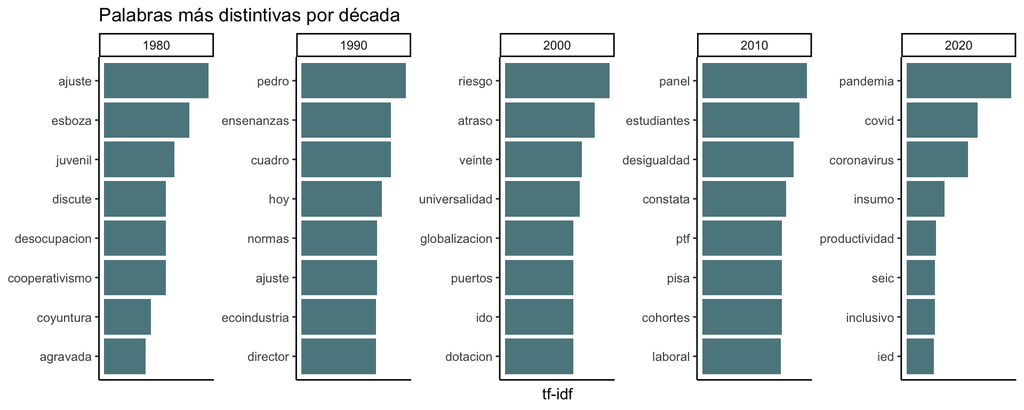

```r
tfidf %>%
  group_by(decada) %>%
  slice_max(tf_idf, n = 8, with_ties = FALSE) %>%
  ungroup() %>%
  ggplot(aes(tf_idf, reorder_within(word, tf_idf, decada))) +
  geom_col(fill = "#5D878E") +
  facet_wrap(~ decada, scales = "free", nrow = 1) +
  scale_y_reordered() +
  labs(x = "tf-idf", y = NULL,
       title = "Palabras más distintivas por década") +
  theme_classic(base_size = 11) +
  theme(axis.text.x = element_blank(), axis.ticks.x = element_blank())
```

Con sólo cinco “documentos”, una palabra que aparece unas pocas veces en una sola década recibe el idf máximo, $\ln 5$. Por eso aparecen palabras raras. Repitamos el gráfico quedándonos sólo con las palabras que aparecen **al menos 5 veces** en la década, y guardémoslo en `03_Resultados/03_tfidf.png`.

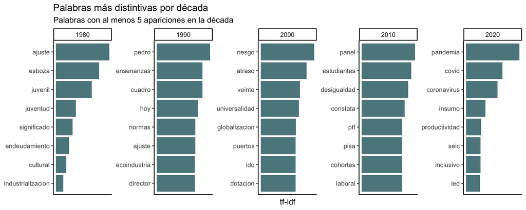

```r
tfidf %>%
  filter(n >= 5) %>%
  group_by(decada) %>%
  slice_max(tf_idf, n = 8, with_ties = FALSE) %>%
  ungroup() %>%
  ggplot(aes(tf_idf, reorder_within(word, tf_idf, decada))) +
  geom_col(fill = "#5D878E") +
  facet_wrap(~ decada, scales = "free", nrow = 1) +
  scale_y_reordered() +
  labs(x = "tf-idf", y = NULL,
       title = "Palabras más distintivas por década",
       subtitle = "Palabras con al menos 5 apariciones en la década") +
  theme_classic(base_size = 11) +
  theme(axis.text.x = element_blank(), axis.ticks.x = element_blank())
```

```r
ggsave("03_Resultados/03_tfidf.png", width = 10, height = 4)
```

# De tidy a DTM

Hasta ahora trabajamos en formato *tidy*. Muchos modelos (LDA, Lasso, clasificadores) piden la **matriz documento-término**. `cast_dtm()` nos permite hacer la conversión. Veamos cómo hacerlo.

En `02_Scripts/05_dtm.R`:

```r
# ==============================================================================
# 05_dtm.R
# Autor: Ignacio Sarmiento-Barbieri
# Descripción: Convierte los tokens limpios en una matriz documento-término (artículo x palabra) y la guarda en dtm.rds para la próxima clase.
# ==============================================================================

library(pacman)
p_load("tidyverse", "tidytext", "tm")

limpios <- readRDS("01_Datos/tokens.rds")

dtm <- limpios %>%
  count(id, word) %>%
  cast_dtm(id, word, n)

dtm
```

```
<<DocumentTermMatrix (documents: 938, terms: 10859)>>
Non-/sparse entries: 60546/10125196
Sparsity           : 99%
Maximal term length: 29
Weighting          : term frequency (tf)
```

Una esquina de la matriz:

```r
as.matrix(dtm[1:6, c("desarrollo", "deuda", "inflacion", "pobreza", "genero", "pandemia")])
```

```
                                       Terms
Docs                                    desarrollo deuda inflacion pobreza
  oai:repositorio.cepal.org:11362/10210          0     0         0       0
  oai:repositorio.cepal.org:11362/10232          0     0         0       0
  oai:repositorio.cepal.org:11362/10243          0     0         0       0
  oai:repositorio.cepal.org:11362/10254          0     0         0       0
  oai:repositorio.cepal.org:11362/10276          1     0         0       1
  oai:repositorio.cepal.org:11362/10287          0     0         0       0
                                       Terms
Docs                                    genero pandemia
  oai:repositorio.cepal.org:11362/10210      0        0
  oai:repositorio.cepal.org:11362/10232      0        0
  oai:repositorio.cepal.org:11362/10243      0        0
  oai:repositorio.cepal.org:11362/10254      0        0
  oai:repositorio.cepal.org:11362/10276      0        0
  oai:repositorio.cepal.org:11362/10287      0        0
```

```r
saveRDS(dtm, "01_Datos/dtm.rds")
```

# Bigramas y co-ocurrencias

La bolsa de palabras (BOW) ignora el orden. Podemos recuperar un poco de él de dos formas: con **bigramas** (dos palabras seguidas) y con **co-ocurrencias** (dos palabras en el mismo resumen).

## Bigramas

En `02_Scripts/06_bigramas.R`, `unnest_tokens()` con `token = "ngrams"` y `n = 2` produce bigramas. Después los separamos en dos columnas y nos quedamos con los bigramas cuyas dos palabras sobrevivieron a la limpieza del paso anterior (sin vacías, sin números, sin las del dominio):

```r
# ==============================================================================
# 06_bigramas.R
# Autor: Ignacio Sarmiento-Barbieri
# Descripción: Cuenta los bigramas más frecuentes por década y dibuja la red de palabras que co-ocurren en los mismos resúmenes.
# ==============================================================================

library(pacman)
p_load("tidyverse", "tidytext", "stopwords", "widyr", "igraph", "ggraph")

cepal   <- readRDS("01_Datos/cepal.rds")
limpios <- readRDS("01_Datos/tokens.rds")

sin_tilde <- function(x) stringi::stri_trans_general(x, "Latin-ASCII")
vacias <- sin_tilde(c(stopwords::stopwords("es", source = "snowball"), stopwords::stopwords("en")))

vocabulario <- unique(limpios$word)  # las palabras que sobrevivieron a la limpieza

bigramas <- cepal %>%
  unnest_tokens(bigrama, resumen, token = "ngrams", n = 2) %>%
  mutate(bigrama = sin_tilde(bigrama)) %>%
  separate(bigrama, into = c("palabra1", "palabra2"), sep = " ") %>%
  filter(palabra1 %in% vocabulario, palabra2 %in% vocabulario)

bigramas %>%
  count(palabra1, palabra2, sort = TRUE) %>%
  head(15)
```

```
# A tibble: 15 × 3
   palabra1    palabra2             n
   <chr>       <chr>            <int>
 1 america     latina             309
 2 crecimiento economico          102
 3 largo       plazo               84
 4 desarrollo  economico           50
 5 paises      latinoamericanos    49
 6 recursos    naturales           45
 7 politica    economica           42
 8 mercado     laboral             39
 9 anos        ochenta             38
10 politicas   publicas            37
11 cada        vez                 34
12 proteccion  social              33
13 estructura  productiva          31
14 corto       plazo               30
15 inversion   extranjera          30
```

Ahora los bigramas más frecuentes por década, sin “america latina”, que está en todas:

```r
bigramas %>%
  unite(bigrama, palabra1, palabra2, sep = " ") %>%
  filter(bigrama != "america latina") %>%
  count(decada, bigrama) %>%
  group_by(decada) %>%
  slice_max(n, n = 5, with_ties = FALSE) %>%
  summarise(bigramas = paste(bigrama, collapse = ", ")) %>%
  deframe()  # vector con nombres: se imprime completo
```

```
                                                                                                1980
  "deuda externa, paises latinoamericanos, crisis economica, sector externo, comercio internacional"
                                                                                                1990
                 "anos ochenta, largo plazo, politica economica, recursos naturales, sector publico"
                                                                                                2000
           "crecimiento economico, largo plazo, desarrollo economico, ultimos anos, mercado laboral"
                                                                                                2010
"crecimiento economico, largo plazo, mercado laboral, desarrollo economico, paises latinoamericanos"
                                                                                                2020
     "crecimiento economico, largo plazo, estructura productiva, coronavirus covid, insumo producto"
```

## Co-ocurrencias

Un bigrama exige que las palabras estén una al lado de la otra. Una co-ocurrencia sólo pide que estén en el mismo resumen. `pairwise_cor()` de `widyr` calcula, para cada par de palabras, la correlación (coeficiente phi) entre “la palabra 1 está en el resumen” y “la palabra 2 está en el resumen”. Analicemos, por ejemplo, las palabras que están en al menos 30 resúmenes:

```r
correlaciones <- limpios %>%
  distinct(id, word) %>%
  add_count(word) %>%
  filter(n >= 30) %>%
  pairwise_cor(word, id, sort = TRUE)

correlaciones %>% head(10)
```

```
# A tibble: 10 × 3
   item1      item2      correlation
   <chr>      <chr>            <dbl>
 1 latina     america          0.953
 2 america    latina           0.953
 3 largo      plazo            0.761
 4 plazo      largo            0.761
 5 decadas    ultimas          0.715
 6 ultimas    decadas          0.715
 7 extranjera directa          0.658
 8 directa    extranjera       0.658
 9 bruto      interno          0.656
10 interno    bruto            0.656
```

¿Con qué palabras va “inflacion”?

```r
correlaciones %>%
  filter(item1 == "inflacion") %>%
  head(8)
```

```
# A tibble: 8 × 3
  item1     item2           correlation
  <chr>     <chr>                 <dbl>
1 inflacion monetaria             0.424
2 inflacion precios               0.303
3 inflacion tipo                  0.195
4 inflacion cambio                0.187
5 inflacion regimen               0.131
6 inflacion macroeconomicas       0.113
7 inflacion fiscal                0.112
8 inflacion variables             0.106
```

O, por ejemplo, ¿cuáles aparecen con *desigualdad* y *comercio*?

```r
correlaciones %>%
  filter(item1 %in% c("desigualdad", "comercio")) %>%
  group_by(item1) %>%
  slice_max(correlation, n = 5) %>%
  ungroup()
```

```
# A tibble: 10 × 3
   item1       item2         correlation
   <chr>       <chr>               <dbl>
 1 comercio    exportaciones       0.348
 2 comercio    comerciales         0.306
 3 comercio    comercial           0.234
 4 comercio    mundial             0.220
 5 comercio    internacional       0.218
 6 desigualdad distribucion        0.255
 7 desigualdad ingresos            0.232
 8 desigualdad ingreso             0.220
 9 desigualdad reduccion           0.202
10 desigualdad pobreza             0.159
```

# Resumiendo

Hoy empezamos con la pregunta: **¿cómo cambió el lenguaje del desarrollo en América Latina en las últimas cinco décadas?**

Esto nos obligó a limpiar el texto y encontramos que:

- Las palabras más frecuentes no dicen nada.
- Limpiar implica tomar decisiones.
- TF-IDF muestra lo distintivo.
- La DTM es la $X$ de siempre, pero con 10.859 columnas y casi todo ceros.
- Bigramas y co-ocurrencias recuperan un poco de estructura.

# Qué entregar

Un `.zip` de la carpeta `Laboratorio_11` con el trabajo de hoy en **Bloque Neón**.